# New Dry Weight and Threshold conversions

# Data Preparation

We’ll start by working with the raw azmp data and the vertically corrected ecomon dataset.

```r
root <- "/mnt/ecocast/projectdata/calanusclimate/src"

azmp <- azmpcfin::read_calanus()
e_corr <- readr::read_csv(file.path(root, "vertical_correction_ecomon.csv.gz"),
                          col_types = readr::cols())
```

To support the dry weight and threshold conversions, we must assign each point to a region.

All ecomon points are in the region “gom”.

```r
e_corr <- mutate(e_corr,
                 region_tc = "gom")
```

AZMP regions are defined based on transect and station, using the methods provided by Caroline.

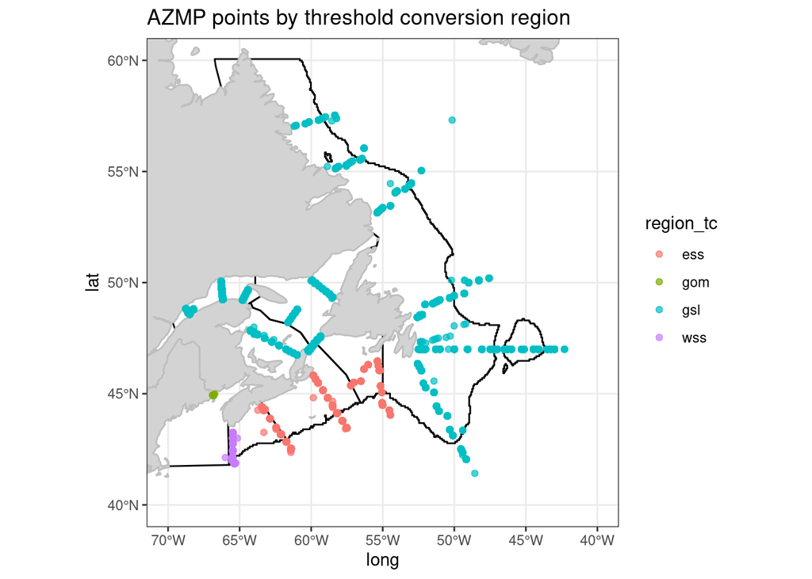

```r
# computing region_vd
get_region_vd <- function(transect, station) {
  if (is.na(transect)) {
    "gom"
  } else if (transect == "BBL") {
    "wss"
  } else if (transect %in% c("HL", "LL", "SESPB", "SWSPB") ||
             station == "HL2") {
    "ess"
  } else if (station == "P5") {
    "gom"
  } else {
    "gsl"
  }
}

azmp <- azmp |>
  mutate(region_tc = purrr::map2(transect, station, get_region_vd) |>
           unlist())
```

Then, we bind the two datasets together and merge it with Brickman datapoints.

```r
ae <- readr::read_csv(file.path(root, "ae_regionvd_cfin.csv.gz"),
                      col_types = readr::cols())

head(ae)
```

```
## # A tibble: 6 × 18
##     lon   lat Bathy_de…¹ land_…²   SST   MLD   SSS  Sbtm  Tbtm        U        V
##   <dbl> <dbl>      <dbl>   <dbl> <dbl> <dbl> <dbl> <dbl> <dbl>    <dbl>    <dbl>
## 1 -66.2  49.5      323.        1 1.23   8.63  27.6  34.4  4.86 -1.04e-2 -0.00873
## 2 -66.3  49.9      260.        1 1.25   9.30  27.7  34.3  4.70  2.61e-3  0.00304
## 3 -66.2  50.0      142.        1 1.40   7.98  28.2  33.2  3.52 -3.08e-4 -0.00376
## 4 -68.5  48.6       70.3       1 0.991  4.74  26.8  32.5  3.49  5.69e-3  0.00950
## 5 -68.5  48.7      210.        1 1.14   8.80  27.1  33.9  4.28  7.34e-3  0.00618
## 6 -68.5  48.7      210.        1 1.14   8.80  27.1  33.9  4.28  7.34e-3  0.00618
## # … with 7 more variables: Xbtm <dbl>, src <chr>, id <chr>, date <date>,
## #   region_tc <chr>, abundance <dbl>, month <dbl>, and abbreviated variable
## #   names ¹Bathy_depth, ²land_mask
```

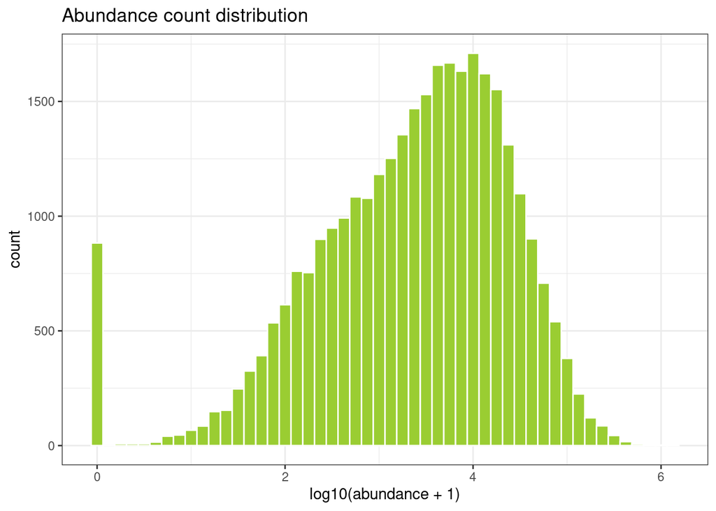

# Dry Weight Conversion

I’m using averaged IDW estimates pulled from Sorochan et. al 2019.

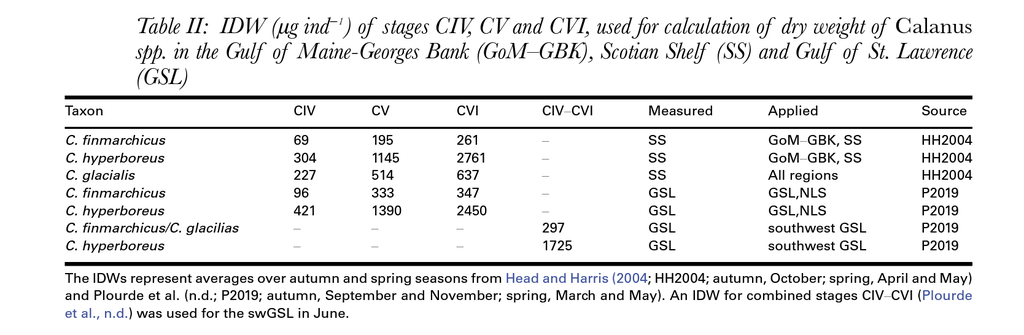

Sorochan et. al 2019, Table 2

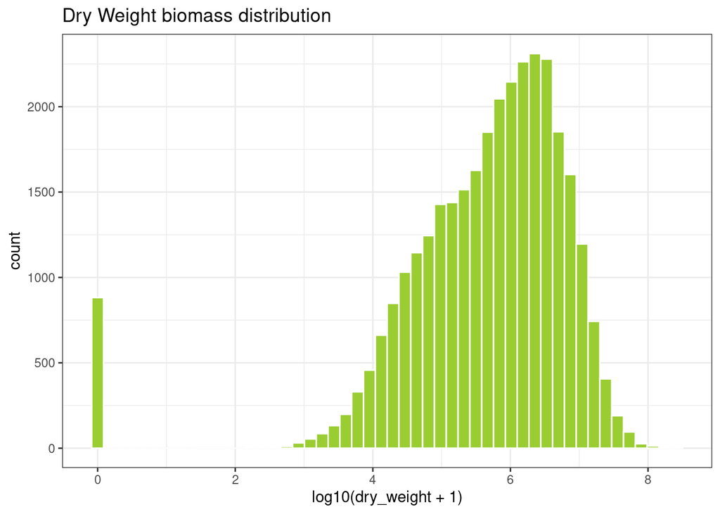

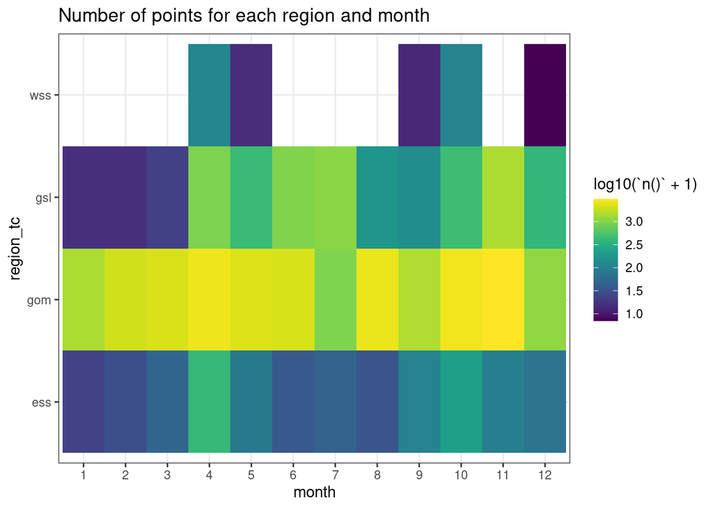

```r
ae_dw <- ae |>
  mutate(dry_weight = abundance *
           map(region_tc, ~ifelse(.x == "gsl", 333, 195)) |> unlist())
```

# Threshold Conversion

Next, we convert from dry weight to threshold. Threshold is computed based off of region and bathymetry. We use the lookup table provided by caroline to determine the biomass threshold at a given point.

Some months performed badly in analyses, and so we map predictions to adjacent months instead.

```r
month_map <- matrix(c(
  11, 11, 4, 4, 6, 6, 6, 9, 9, 10, 11, 11,
  11, 11, 4, 4, 5, 6, 6, 9, 9, 10, 11, 11,
  11, 11, 3, 5, 5, 6, 7, 8, 9, 11, 11, 11,
  1, 1, 4, 4, 4, 7, 7, 8, 8, 12, 12, 12),
  nrow = 12,
  dimnames = list(c(1, 2, 3, 4, 5, 6, 7, 8, 9, 10, 11, 12), c("ess", "wss", "gsl", "gom"))
)

ae_thresholds <- ae_dw |>
  rowwise() |>
  mutate(tmonth = month_map[[month, region_tc]]) |>
  ungroup()
```

```
##    patch     n     percent
## 1: FALSE 32128 0.998756528
## 2:  TRUE    40 0.001243472
```

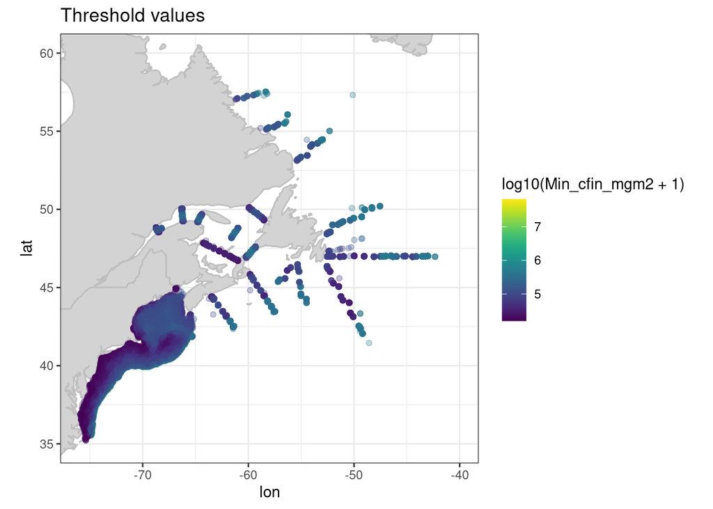

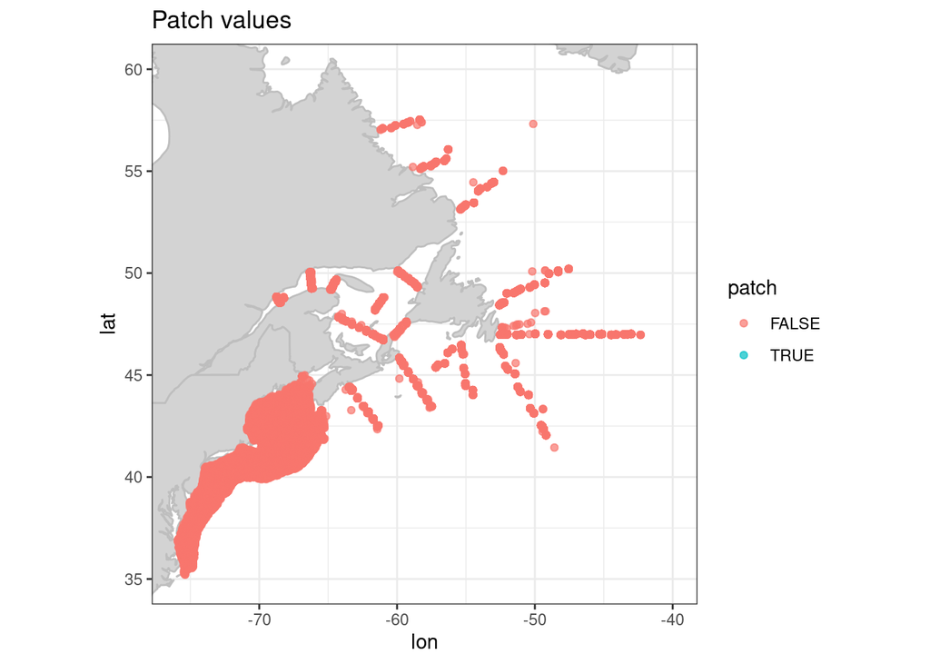

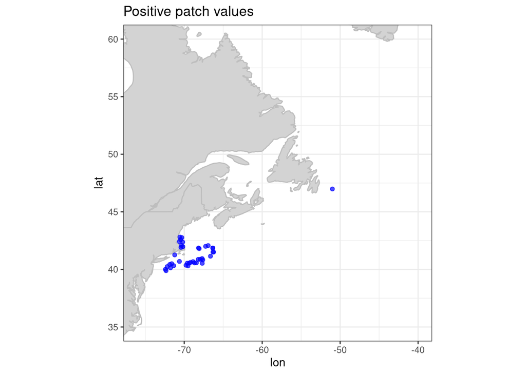

```r
thresholds <- read.table("Calanus_threshold.txt", header = TRUE) |>
  group_by(month, region_vd)

tkeys <- group_keys(thresholds)
tlist <- group_split(thresholds, .keep = FALSE) |>
  map(~as.data.table(.x) |>
        setkey(depth))
names(tlist) <- paste(tkeys$region_vd, tkeys$month)

ae_thresholds <- ae_thresholds |>
  group_by(tmonth, region_tc) |>
  group_split() |>
  lapply(function(a) tlist[[paste(a[[1, "region_tc"]], a[[1, "month"]])]]
         [J(a$Bathy_depth), roll = "nearest"] |>
           select(Min_cfin_mgm2) |>
           bind_cols(a)) |>
  bind_rows() |>
  mutate(patch = dry_weight >= 1000 * Min_cfin_mgm2)

count(ae_thresholds, patch) |>
  mutate(percent = n/sum(n))
```